# HW6

Anish Mohan

November 9, 2015

# Q1

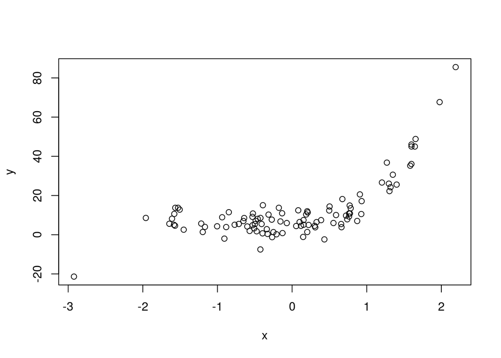

```r
x=rnorm(100)
eps=rnorm(100)
y=5+2*x+7*x*x+3*x*x*x+5*eps
plot(x,y)
```

```r
u=lm(y~-1)
u0=lm(y~1)
u1=lm(y~poly(x,1))
u2=lm(y~poly(x,2))
u3=lm(y~poly(x,3))
u4=lm(y~poly(x,4))
u5=lm(y~poly(x,5))
xlim=range(x)
xgrid=seq(from=xlim[1],to=xlim[2], length.out = 100)
```

- 1a. $\lambda=\infty$, m=0

  Since $\lambda=\infty$, to minimize the equation, we need $g^{(0)}$ be zero or tend towards zero. This is possible with a function g(x)=0

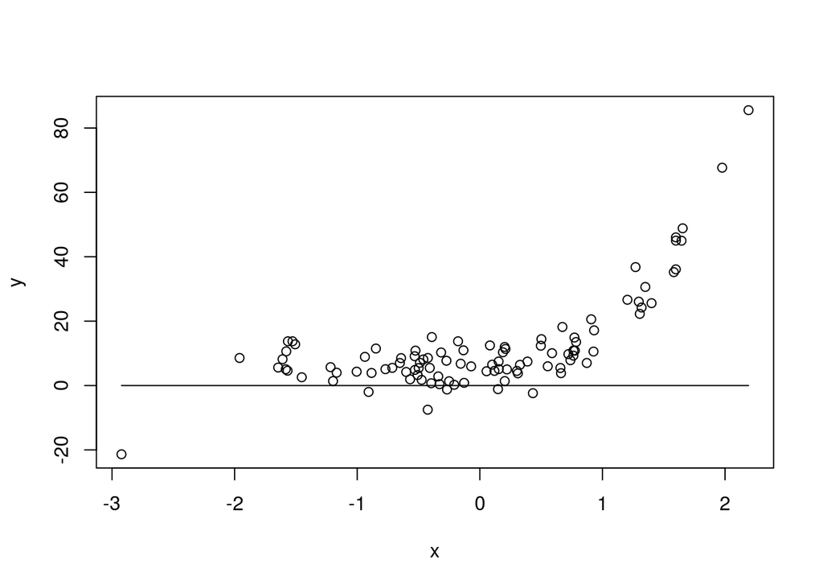

  ```r
    plot(x,y)
  tempval=rep(0,100)
  lines(xgrid,tempval)
  ```

- 1b. $\lambda=\infty$, m=1

  Since $\lambda=\infty$, to minimize the equation, we need $g^{(1)}$ to be lowest or tend towards zero. This is only possible if $g(x)$ is a constant function i.e g(x)= $\beta_{0}$

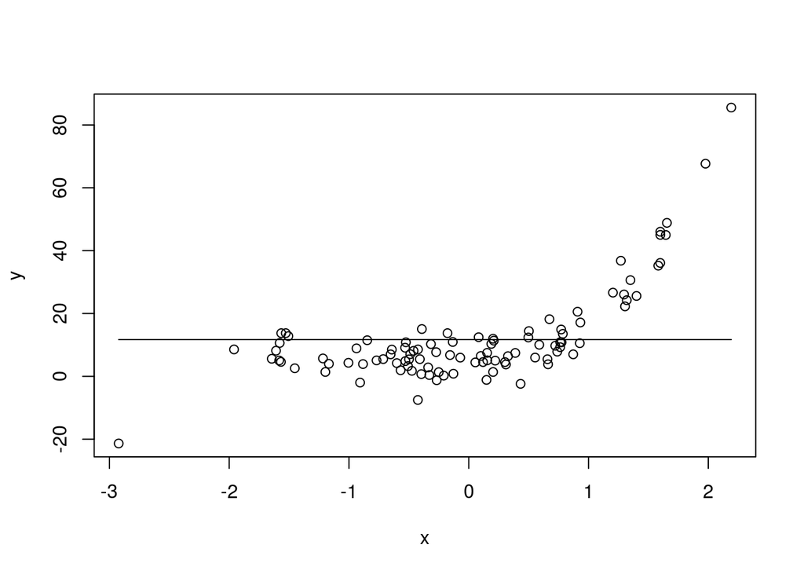

  ```r
  plot(x,y)
  val=u0$coefficients[1]
  tempval=rep(val,100)
  lines(xgrid,tempval)
  ```

- 1c. $\lambda=\infty$, m=2

  Since $\lambda=\infty$, to minimize the equation, we need $g^{(2)}$ to be lowest or tend towards zero. This is possible if $g^{(1)}$ is constant i.e $g(x)$ is a linear function with constant slope. Hence the function would be g(x)=$\beta_{0}+\beta_{1}*x$.

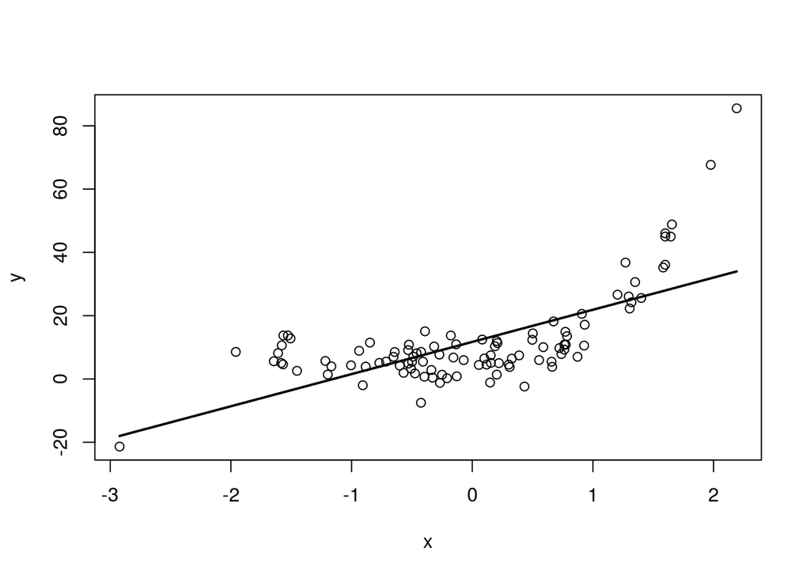

  ```r
  plot(x,y)
  xlim=range(x)
  xgrid=seq(from=xlim[1],to=xlim[2], length.out = 100)
  pred=predict(u1,newdata=list(x=xgrid),se=T)
  lines(xgrid, pred$fit, lwd=2)
  ```

- 1d. $\lambda=\infty$, m=3

  Since $\lambda=\infty$, to minimize the equation, we need $g^{(3)}$ to be lowest or tend towards zero. This is possible if $g^{(2)}$ is constant. This implied $g^{(1)}$ is uniformly increasing or has constant slope i.e the function $g(x)$ would be incresing at a constant rate. This is possible with a function g(x)=$\beta_{0}+\beta_{1}*x+\beta_{2}*x^2$

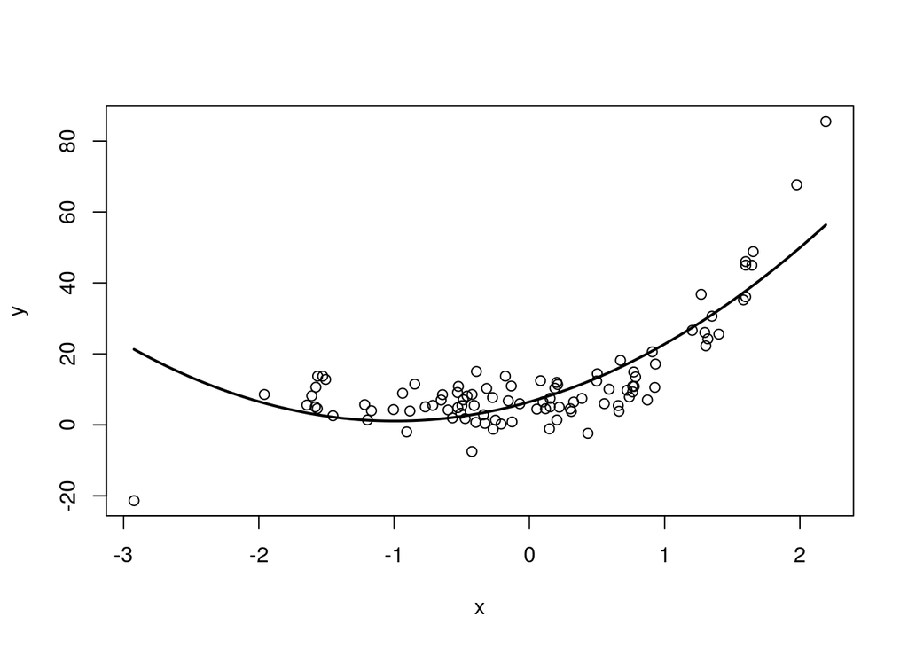

  ```r
  plot(x,y)
  xlim=range(x)
  xgrid=seq(from=xlim[1],to=xlim[2], length.out = 100)
  pred=predict(u2,newdata=list(x=xgrid),se=T)
  lines(xgrid, pred$fit, lwd=2)
  ```

  - 1e. $\lambda=0$, m=3

  Since $\lambda=0$, to minimize the equation, we need residual erro to be lowest. This is possible with a function that minimizes the RSS which in this case is g(x)=$\beta_{0}+\beta_{1}*x+\beta_{2}*x^2+\beta_{3}*x^3$ a shown by low p value from the summary results.

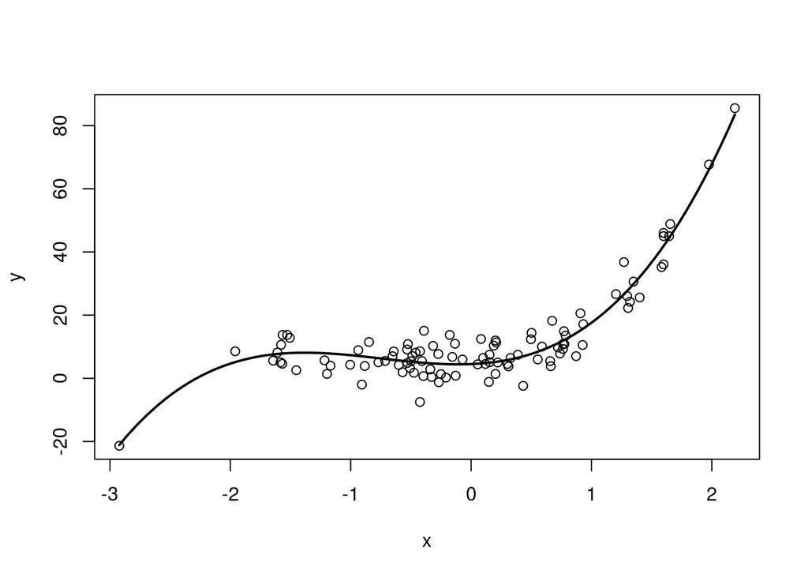

  ```r
  plot(x,y)
  xlim=range(x)
  xgrid=seq(from=xlim[1],to=xlim[2], length.out = 100)
  pred=predict(u3,newdata=list(x=xgrid),se=T)
  lines(xgrid, pred$fit, lwd=2)
  ```

  ```r
  summary(u4)
  ```

  ```
  ##
  ## Call:
  ## lm(formula = y ~ poly(x, 4))
  ##
  ## Residuals:
  ##      Min       1Q   Median       3Q      Max
  ## -12.7286  -3.3987  -0.1952   3.0947  10.5503
  ##
  ## Coefficients:
  ##             Estimate Std. Error t value Pr(>|t|)
  ## (Intercept)  11.7066     0.4578  25.571   <2e-16 ***
  ## poly(x, 4)1  99.6283     4.5780  21.762   <2e-16 ***
  ## poly(x, 4)2  69.9315     4.5780  15.275   <2e-16 ***
  ## poly(x, 4)3  67.6184     4.5780  14.770   <2e-16 ***
  ## poly(x, 4)4   3.0501     4.5780   0.666    0.507
  ## ---
  ## Signif. codes:  0 '***' 0.001 '**' 0.01 '*' 0.05 '.' 0.1 ' ' 1
  ##
  ## Residual standard error: 4.578 on 95 degrees of freedom
  ## Multiple R-squared:  0.9069, Adjusted R-squared:  0.903
  ## F-statistic: 231.4 on 4 and 95 DF,  p-value: < 2.2e-16
  ```

# Q2

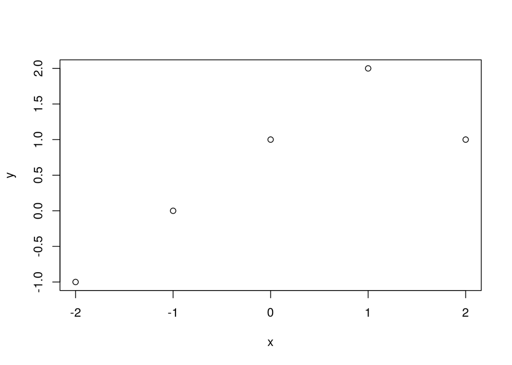

```r
      x=-2:2
      beta0=1
      beta1=1
      beta2=-2
      y=rep(NA,5)

      for(i in 1:5 ) {
        if(x[i]<1){
          y[i]=beta0+x[i]*beta1
        } else {
          y[i]=beta0+beta1*x[i]+beta2*(x[i]-1)^2
        }
      }
      plot(x,y)
```

# Q3

- 3a. Functions $\hat{g_2}$ will have a smaller training error as it is higher order polynomial and has higher order penalty function. It will fit the training data well
- 3b. Functions $\hat{g_1}$ could have a smaller test error as the higher order function $\hat{g_2}$ will tend to overfit the noise.
- 3c. Functions $\hat{g_1}$ and $\hat{g_2}$ are same when $\lambda=0$, hence they will have same training and test error.

# Q4

```r
      library(ISLR)
      library(boot)
      attach(Auto)

      set.seed(1)
      #10-Fold validation comparing a linear and cubic model

      fit.lm=glm(mpg~horsepower, data=Auto)
      cv.error=cv.glm(Auto,fit.lm,K=10)
      cv.error$delta
```

```
## [1] 24.10716 24.09865
```

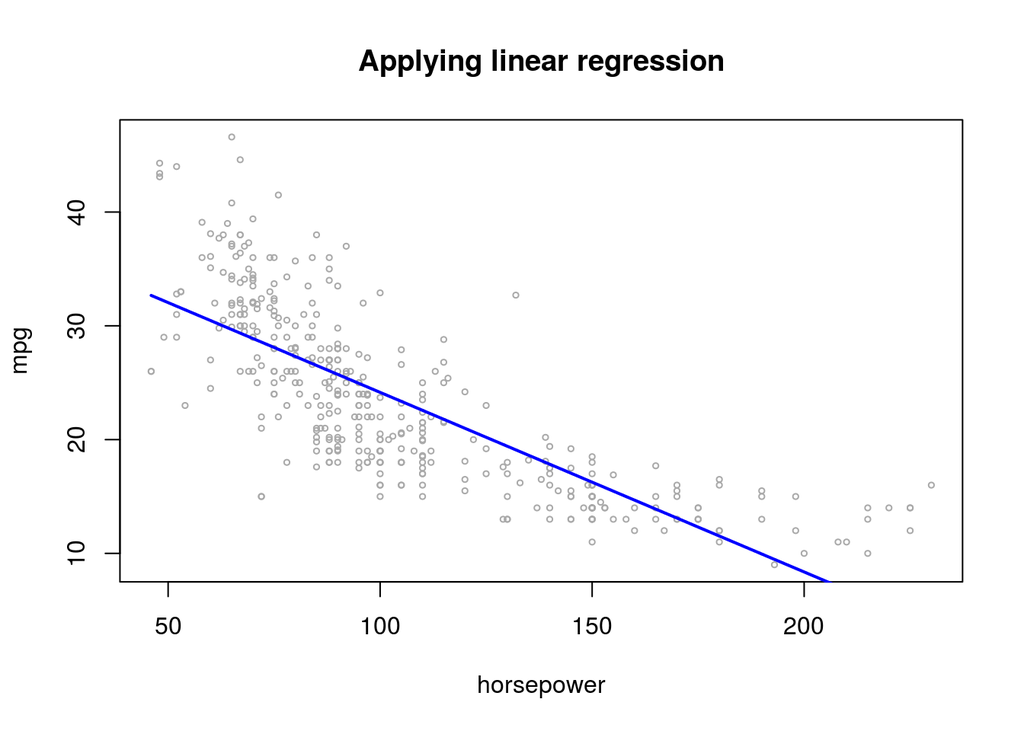

```r
      hplims=range(Auto$horsepower)
      hp.grid=seq(from=hplims[1],to=hplims[2])

      plot(horsepower, mpg, xlim=hplims, cex=0.5, col="darkgrey")
      preds=predict(fit.lm,newdata=list(horsepower=hp.grid), se=T)
      lines(hp.grid, preds$fit, lwd=2, col="blue")
      title("Applying linear regression")
```

```r
      fit.poly=glm(mpg~poly(horsepower,3),data=Auto)
      cv.error=cv.glm(Auto,fit.poly,K=10)
      cv.error$delta
```

```
## [1] 19.37347 19.35072
```

```r
      print(paste0("Error from polynomial regression is smaller than linear regression" ))
```

```
## [1] "Error from polynomial regression is smaller than linear regression"
```

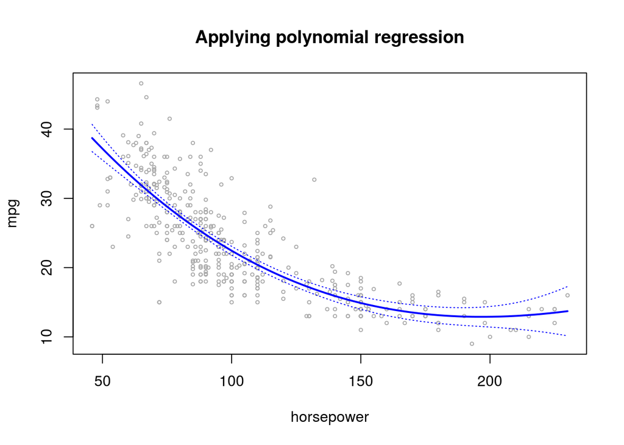

```r
      #Using Polynomial regression

      preds=predict(fit.poly,newdata=list(horsepower=hp.grid), se=T)
      se.bands=cbind(preds$fit+2*preds$se,preds$fit-2*preds$se.fit)

      plot(horsepower, mpg, xlim=hplims, cex=0.5, col="darkgrey")
      title("Applying polynomial regression")
      lines(hp.grid, preds$fit, lwd=2, col="blue")
      matlines(hp.grid, se.bands, lwd=1, col="blue", lty=3)
```

```r
      #using  ANOVA to analyze variance.
      fit.1=lm(mpg~horsepower, data=Auto)
      fit.2=lm(mpg~poly(horsepower,2), data=Auto)
      fit.3=lm(mpg~poly(horsepower,3), data=Auto)
      fit.4=lm(mpg~poly(horsepower,4), data=Auto)

      anova(fit.1,fit.2,fit.3,fit.4)
```

```
## Analysis of Variance Table
##
## Model 1: mpg ~ horsepower
## Model 2: mpg ~ poly(horsepower, 2)
## Model 3: mpg ~ poly(horsepower, 3)
## Model 4: mpg ~ poly(horsepower, 4)
##   Res.Df    RSS Df Sum of Sq        F Pr(>F)
## 1    390 9385.9
## 2    389 7442.0  1   1943.89 101.6666 <2e-16 ***
## 3    388 7426.4  1     15.59   0.8155 0.3670
## 4    387 7399.5  1     26.91   1.4076 0.2362
## ---
## Signif. codes:  0 '***' 0.001 '**' 0.01 '*' 0.05 '.' 0.1 ' ' 1
```

```r
      print(paste0("Quadratic model seems to be a good fit"))
```

```
## [1] "Quadratic model seems to be a good fit"
```

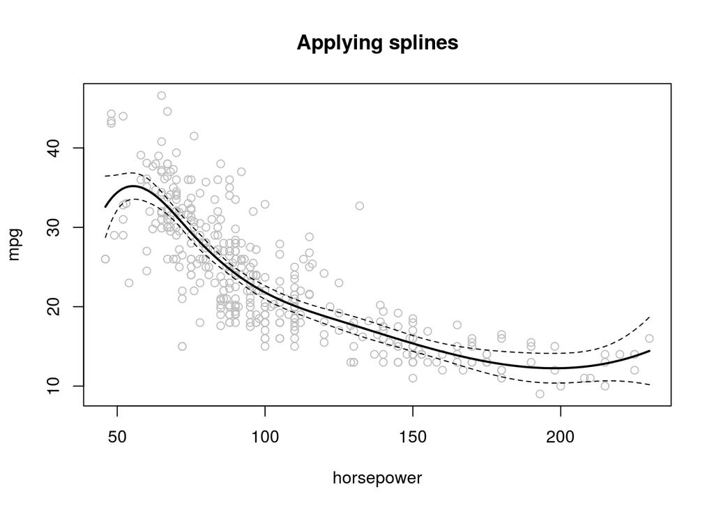

```r
      #Applying spline model
      library(splines)
      fit=lm(mpg~bs(horsepower, df=6),data=Auto)
      pred=predict(fit,newdata=list(horsepower=hp.grid),se=T)
      plot(horsepower,mpg, col="gray")
      title('Applying splines')
      lines(hp.grid, pred$fit,lwd=2)
      lines(hp.grid, pred$fit+2*pred$se,lty="dashed")
      lines(hp.grid, pred$fit-2*pred$se,lty="dashed")
```

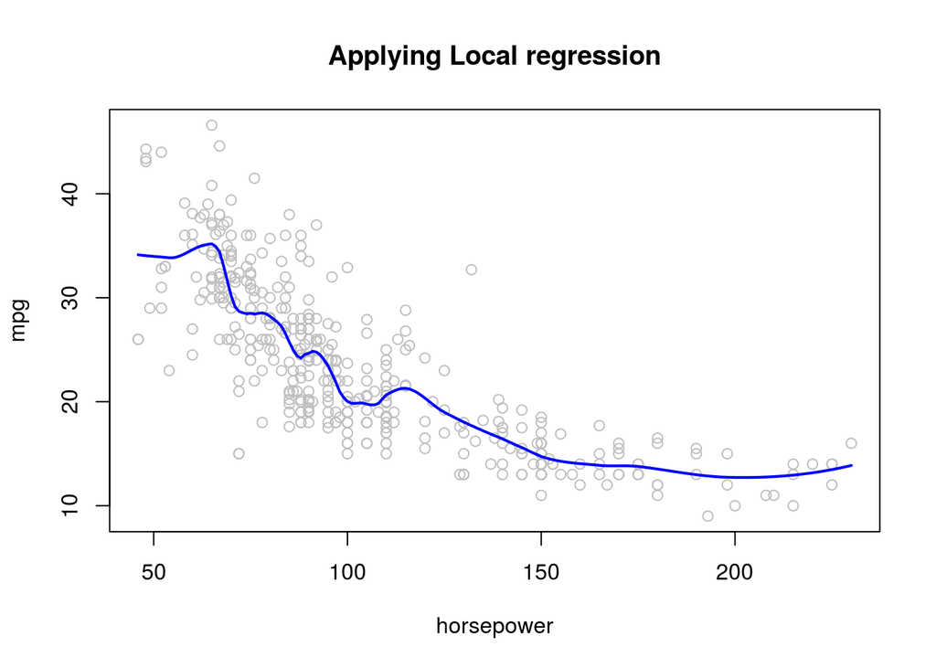

```r
      #Applying local regression
      fit=loess(mpg~horsepower, span=0.2, data=Auto)
      pred=predict(fit, newdata=data.frame(horsepower=hp.grid))
      plot(horsepower,mpg, col="gray")
      title('Applying Local regression')
      lines(hp.grid, pred,col="blue", lwd=2)
```

# Q5

- 5a.

  ```r
    library(MASS)
    attach(Boston)

    fit.poly=glm(nox~poly(dis,3))
    print(paste0("Coefficient of the polynomial eqn"))
  ```

  ```
  ## [1] "Coefficient of the polynomial eqn"
  ```

  ```r
    coef(fit.poly)
  ```

  ```
  ##   (Intercept) poly(dis, 3)1 poly(dis, 3)2 poly(dis, 3)3
  ##     0.5546951    -2.0030959     0.8563300    -0.3180490
  ```

  ```r
    summary(fit.poly)
  ```

  ```
  ##
  ## Call:
  ## glm(formula = nox ~ poly(dis, 3))
  ##
  ## Deviance Residuals:
  ##       Min         1Q     Median         3Q        Max
  ## -0.121130  -0.040619  -0.009738   0.023385   0.194904
  ##
  ## Coefficients:
  ##                Estimate Std. Error t value Pr(>|t|)
  ## (Intercept)    0.554695   0.002759 201.021  < 2e-16 ***
  ## poly(dis, 3)1 -2.003096   0.062071 -32.271  < 2e-16 ***
  ## poly(dis, 3)2  0.856330   0.062071  13.796  < 2e-16 ***
  ## poly(dis, 3)3 -0.318049   0.062071  -5.124 4.27e-07 ***
  ## ---
  ## Signif. codes:  0 '***' 0.001 '**' 0.01 '*' 0.05 '.' 0.1 ' ' 1
  ##
  ## (Dispersion parameter for gaussian family taken to be 0.003852802)
  ##
  ##     Null deviance: 6.7810  on 505  degrees of freedom
  ## Residual deviance: 1.9341  on 502  degrees of freedom
  ## AIC: -1370.9
  ##
  ## Number of Fisher Scoring iterations: 2
  ```

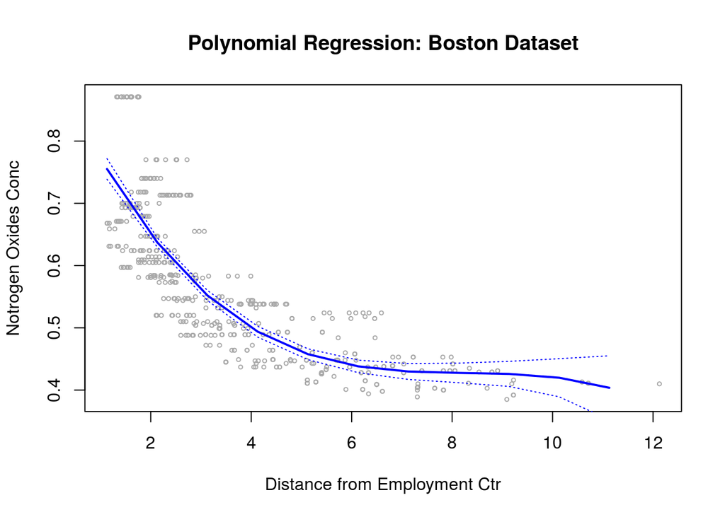

  ```r
    dislims=range(Boston$dis)
    dis.grid=seq(from=dislims[1],to=dislims[2])
    preds=predict(fit.poly,newdata=list(dis=dis.grid), se=T)
    se.bands=cbind(preds$fit+2*preds$se,preds$fit-2*preds$se.fit)

    plot(dis,nox, xlim=dislims,xlab="Distance from Employment Ctr", ylab="Notrogen Oxides Conc", cex=0.5, col="darkgrey")
    title("Polynomial Regression: Boston Dataset")
    lines(dis.grid, preds$fit, lwd=2, col="blue")
    matlines(dis.grid, se.bands, lwd=1, col="blue", lty=3)
  ```

- 5b.

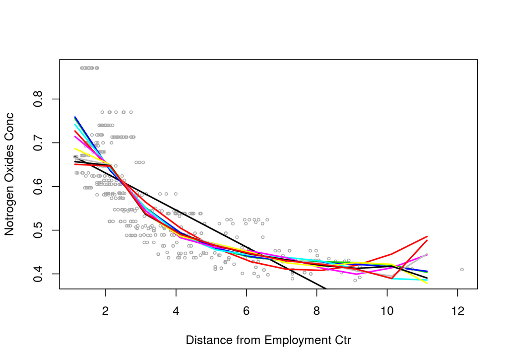

  ```r
    fit=matrix(0,nrow=10,ncol=1)
  plot(dis,nox, xlim=dislims,xlab="Distance from Employment Ctr", ylab="Notrogen Oxides Conc", cex=0.5, col="darkgrey")
  for (i in 1:10){
    lm.fit=glm(nox~poly(dis,i),data=Boston)
    fit[i]=sum(lm.fit$residuals^2)
    preds=predict(lm.fit,newdata=list(dis=dis.grid), se=T)
    lines(dis.grid, preds$fit, lwd=2, col=i)
  }
  ```

  ```r
  fit
  ```

  ```
  ##           [,1]
  ##  [1,] 2.768563
  ##  [2,] 2.035262
  ##  [3,] 1.934107
  ##  [4,] 1.932981
  ##  [5,] 1.915290
  ##  [6,] 1.878257
  ##  [7,] 1.849484
  ##  [8,] 1.835630
  ##  [9,] 1.833331
  ## [10,] 1.832171
  ```

- 5c.

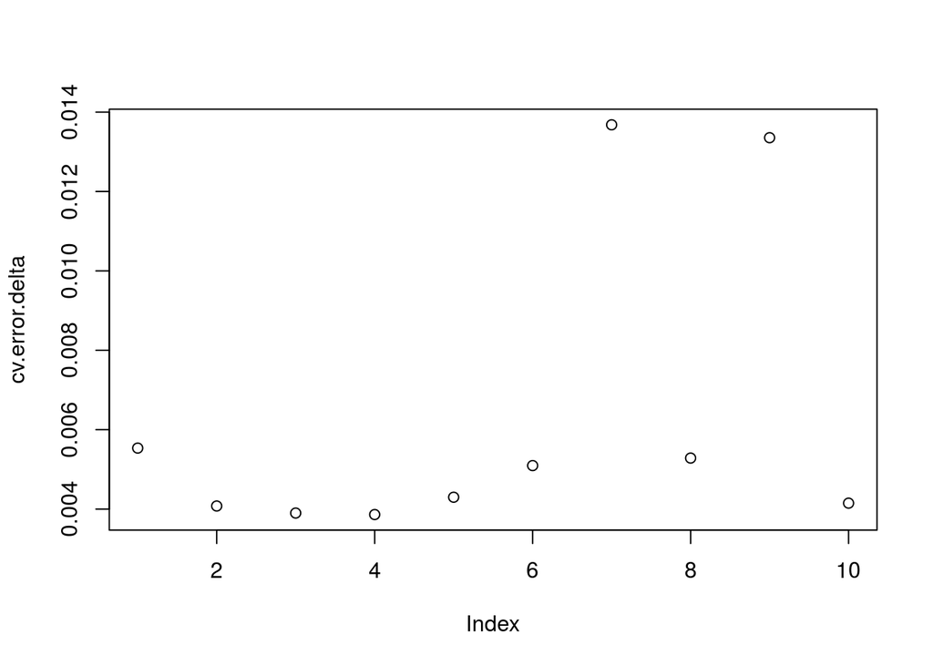

  ```r
    set.seed(1)
    cv.error.delta=rep(NA,10)
    for(i in 1:10){
      fit.poly=glm(nox~poly(dis,i),data=Boston)
      cv.error=cv.glm(Boston,fit.poly,K=10)
      cv.error.delta[i]=cv.error$delta[1]
    }
    plot(cv.error.delta)
  ```

- Degree 4 polynomial is the simplest model with lowest Cross-Validation error.
- A liner model does not fit the data, hence it has higher error. The quadratic and cubic models are comparable as the difference in error between them on a 10 fold CV set is small. Degree 4 polynomial shows the smallest error.
- For polynomials>4, the residual errors are high implying that the model fits to the training data but gives poor results on the CV test data.
- 5d.

  ```r
    library(splines)
  fit=lm(nox~bs(dis,df=4),data=Boston)
  dislims=range(Boston$dis)
  dis.grid=seq(from=dislims[1],to=dislims[2])
  summary(fit)
  ```

  ```
  ##
  ## Call:
  ## lm(formula = nox ~ bs(dis, df = 4), data = Boston)
  ##
  ## Residuals:
  ##       Min        1Q    Median        3Q       Max
  ## -0.124622 -0.039259 -0.008514  0.020850  0.193891
  ##
  ## Coefficients:
  ##                  Estimate Std. Error t value Pr(>|t|)
  ## (Intercept)       0.73447    0.01460  50.306  < 2e-16 ***
  ## bs(dis, df = 4)1 -0.05810    0.02186  -2.658  0.00812 **
  ## bs(dis, df = 4)2 -0.46356    0.02366 -19.596  < 2e-16 ***
  ## bs(dis, df = 4)3 -0.19979    0.04311  -4.634 4.58e-06 ***
  ## bs(dis, df = 4)4 -0.38881    0.04551  -8.544  < 2e-16 ***
  ## ---
  ## Signif. codes:  0 '***' 0.001 '**' 0.01 '*' 0.05 '.' 0.1 ' ' 1
  ##
  ## Residual standard error: 0.06195 on 501 degrees of freedom
  ## Multiple R-squared:  0.7164, Adjusted R-squared:  0.7142
  ## F-statistic: 316.5 on 4 and 501 DF,  p-value: < 2.2e-16
  ```

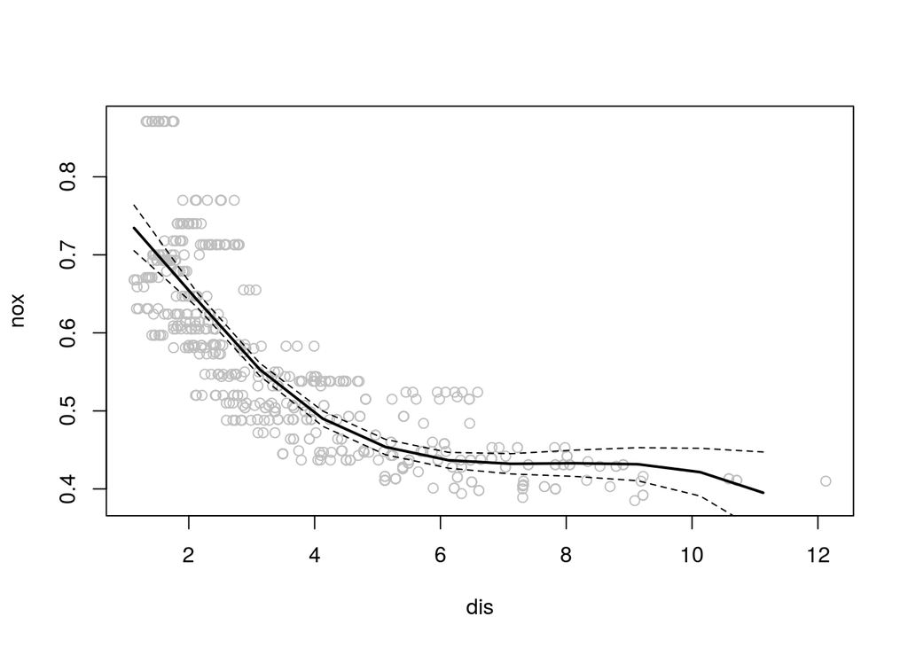

  ```r
  pred=predict(fit,newdata=list(dis=dis.grid), se=T)
  plot(dis,nox, col="gray")
  lines(dis.grid, pred$fit, lwd=2)
  lines(dis.grid, pred$fit+2*pred$se, lty="dashed")
  lines(dis.grid, pred$fit-2*pred$se, lty="dashed")
  ```

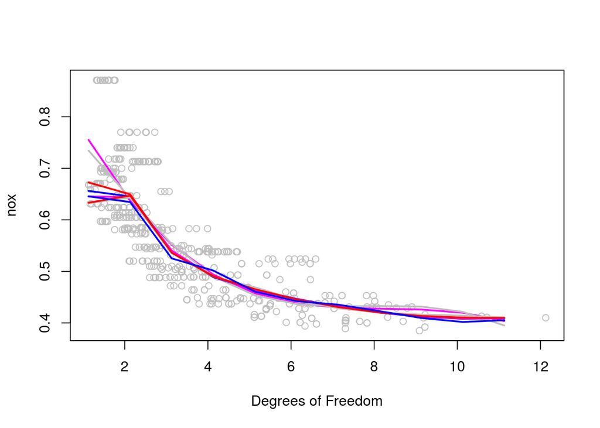

  ```r
  plot(dis,nox, col="gray", xlab="Degrees of Freedom")
  rss=rep(NA,10)
  for(i in 3:10){
    lm.fit=lm(nox~bs(dis,df=i),data=Boston)
    pred=predict(lm.fit,newdata=list(dis=dis.grid), se=T)
    lines(dis.grid, pred$fit, lwd=2, col=i*10)
    rss[i]=sum(lm.fit$residuals^2)
  }
  ```

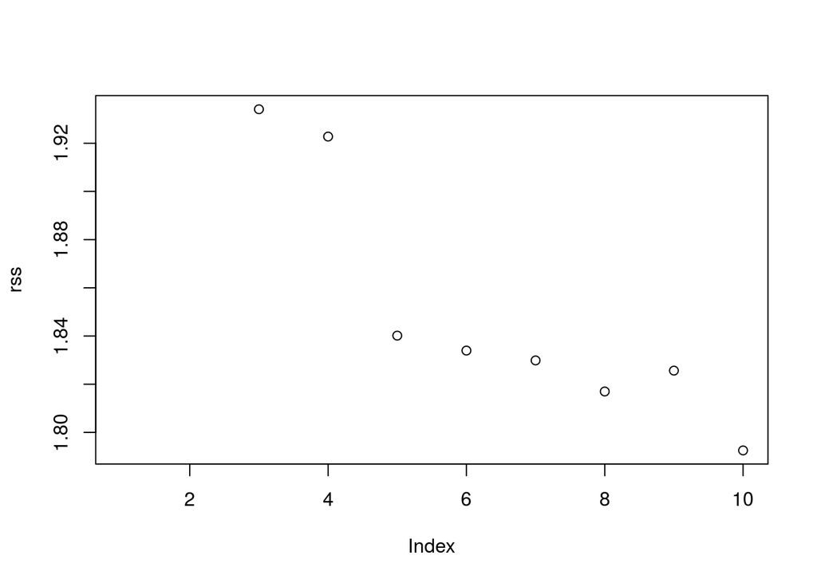

  ```r
  plot(rss)
  ```

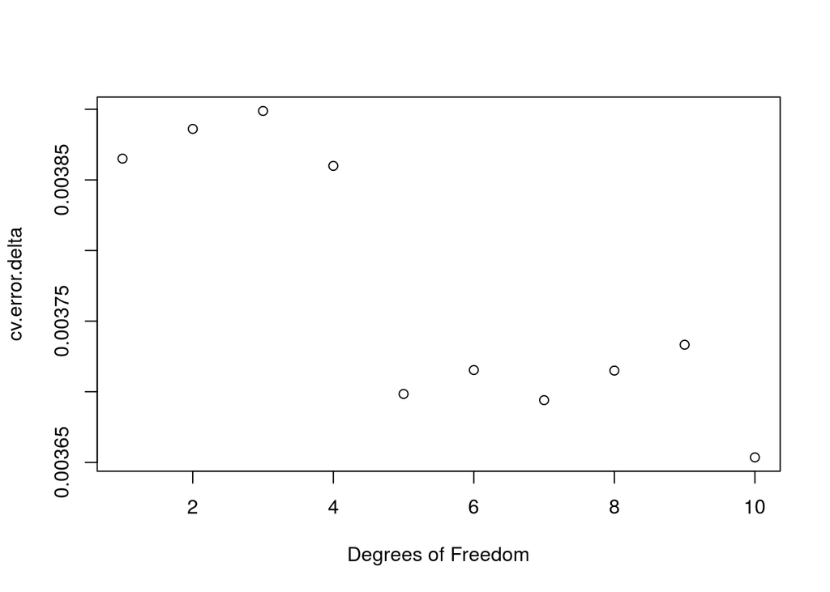

  ```r
  set.seed(1)
  cv.error.delta=rep(NA,10)
  for(i in 1:10){
    fit.spline=glm(nox~bs(dis,df=i),data=Boston)
    cv.error=cv.glm(Boston,fit.spline,K=10)
    cv.error.delta[i]=cv.error$delta[1]
  }
  plot(cv.error.delta, xlab="Degrees of Freedom")
  ```

  - Lowest error obtained through cross validation is for df=10.
  - As we increase the degrees of freedome, initially, till we reach df=3, there is increase in the RSS. However, error starts decreasing after that till df=5. Errors fluctuate a bit, before getting the lowest error at df=10.

# Q6

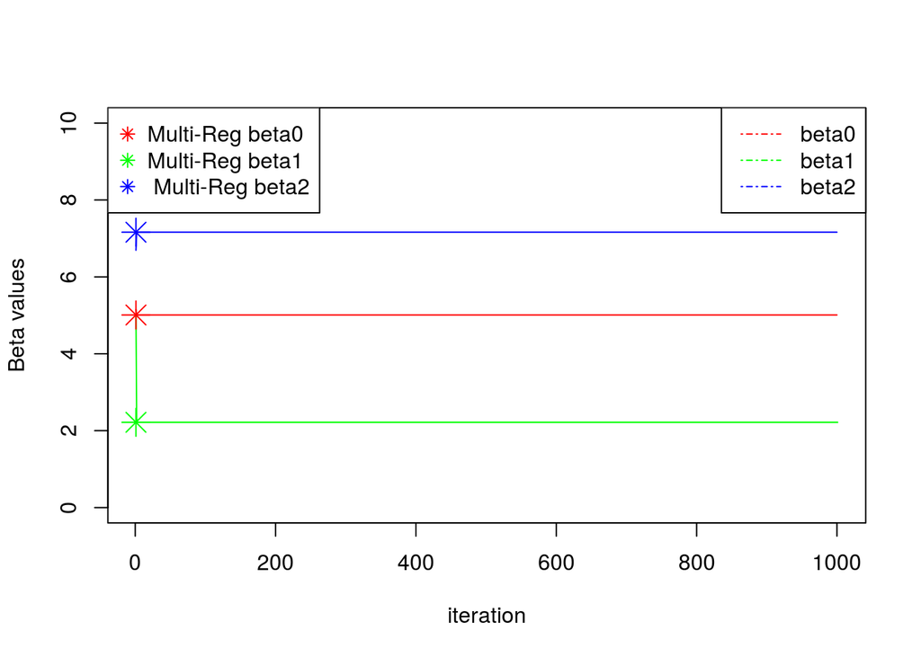

```r
            x1=rnorm(100)
            x2=rnorm(100)
            eps=rnorm(100)
            y=5+2*x1+7*x2+eps

            beta0=rep(NA,1000)
            beta1=rep(NA,1000)
            beta2=rep(NA,1000)

            beta1[1]=5

          for(i in 1:1000){
            a=y-beta1[i]*x1
            beta2[i]=lm(a~x2)$coef[2]
            beta0[i]=lm(a~x2)$coef[1]

           a=y-beta2[i]*x2
            beta1[i+1]=lm(a~x1)$coef[2]

          }

          plot(1:1001,beta1, col="green", type='l', ylim=c(0,10), xlab="iteration", ylab="Beta values")
          lines(1:1000,beta0, col="red")
          lines(1:1000,beta2, col="blue")


          u=lm(y~x1+x2)
          points(coef(u)[1],col="red", pch=8, cex=2)
          points(coef(u)[2],col="green", pch=8, cex=2)
          points(coef(u)[3],col="blue", pch=8, cex=2)
         legend("topright",c("beta0","beta1","beta2"), lty=4,col = c("red","green","blue"))
          legend("topleft",c("Multi-Reg beta0","Multi-Reg beta1"," Multi-Reg beta2"), pch=8,col = c("red","green","blue"))
```

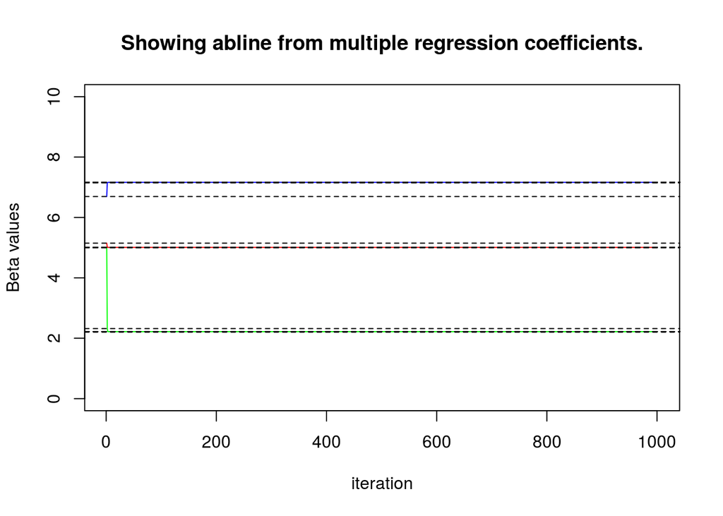

```r
          plot(1:1001,beta1, col="green", type='l', ylim=c(0,10), xlab="iteration", ylab="Beta values")
          title("Showing abline from multiple regression coefficients.")
          lines(1:1000,beta0, col="red")
          lines(1:1000,beta2, col="blue")
          abline(h=beta0, lty="dashed")
          abline(h=beta1, lty="dashed")
          abline(h=beta2, lty="dashed")
```

```r
          print(paste0("Within 2nd approximations the backfitting answers were good estimates"))
```

```
## [1] "Within 2nd approximations the backfitting answers were good estimates"
```

```r
          beta0[1:5]
```

```
## [1] 5.149512 5.014518 5.009577 5.009396 5.009389
```

```r
          beta1[1:5]
```

```
## [1] 5.000000 2.319657 2.221546 2.217955 2.217824
```

```r
          beta2[1:5]
```

```
## [1] 6.693492 7.145315 7.161853 7.162459 7.162481
```